# Predicting Weight Lifting Exercise Effectiveness through Human Activity Recognition

elenapatricia218  
October 25, 2015

### Objective

Predict the manner in which participants were performing a weight lifting exercise (classe) based on different types of Human Activity Recognition. Data were collected in order to measure how well participants conduct a particular exercise. See below “References” section for a more thorough context.

### 1. Data Treatment

Setting up the required packages and identifying a seed make the below reproducible if you should choose to replicate this analysis. Also, splitting the training data into training/testing datasets enables cross-validation before applying purely to the final testing dataset.

```r
library(ggplot2); library(lattice); library(caret); library(rpart); library(randomForest)
set.seed(2564)

# Step 1 - get data for training
fileUrl <- "https://d396qusza40orc.cloudfront.net/predmachlearn/pml-training.csv"
download.file(fileUrl,destfile="./pml-training.csv",method="curl")
pml.training <- read.csv("./pml-training.csv")
# within train, subset out a test dset
inTrain <- createDataPartition(y=pml.training$classe,
                               p=0.7, list=FALSE)
training <- pml.training[inTrain,]
testing <- pml.training[-inTrain,]
```

The most important step is to clean up the data in order to avoid “Garbage In, Garbage Out.” This included scrubbing non-numeric columns, and eliminating any columns which were un-useable (e.g. due to 100% population of NAs, or data which aren’t movements).

```r
# GIGO - clean up the data!
# specify numeric variables
nums <- sapply(training,is.numeric)
# look at the NA problem
na_count <-sapply(training, function(y) sum(length(which(is.na(y)))))
na_count <- data.frame(na_count)
# ok we need to subset nums
training.f <- cbind(training[,nums],training$classe)
colnames(training.f)[124] <- "classe"
# and drop columns that are all na
training.f2 <- training.f[,colSums(is.na(training.f))==0]
# and drop columns which are not movements
training.f2 <- training.f2[,-c(1,2,3,4)]
```

### 2. Fitting Models

**2.1 Preliminary fit**

First, a simple tree method approach was taken.

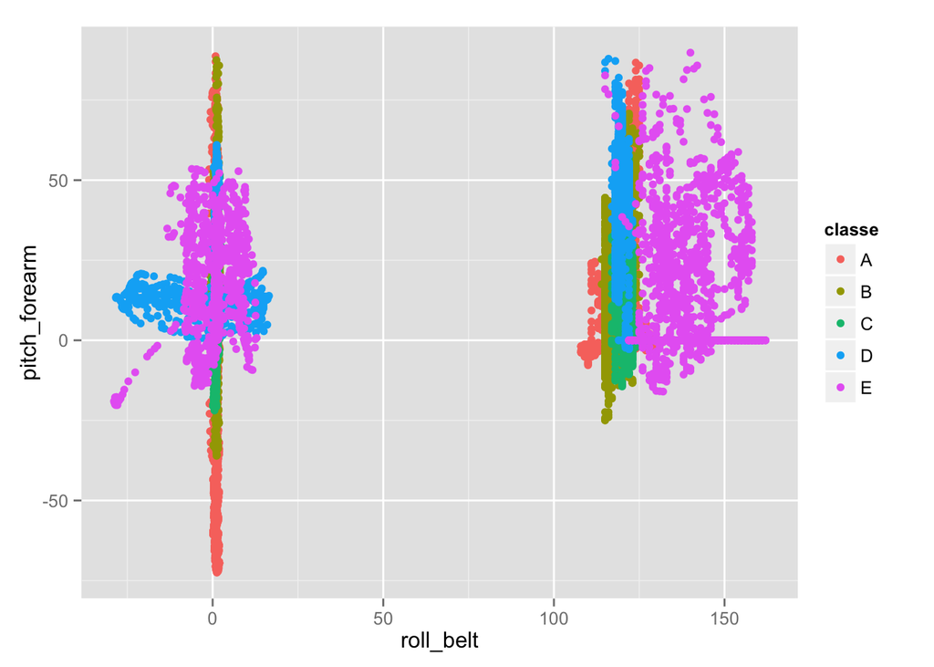

```r
modFit <- train(classe ~ .,method="rpart",data=training.f2)
print(modFit$finalModel)

# check out the top two nodes' influence
qplot(roll_belt,pitch_forearm,colour=classe,data=training)
```

[output not shown]

```r
# look at the tree
#plot(modFit$finalModel,uniform=TRUE,
#     main="Classification Tree")
#text(modFit$finalModel,use.n=TRUE,all=TRUE,cex=.8)

# look at a confusion matrix
pred <- predict(modFit,newdata=training)
confusionMatrix(pred,training$classe)
# yikes, accuracy is only 0.55
```

[output not shown]

```r
# see how it does on testing
# this is the cross-validation
predtest <- predict(modFit,newdata=testing)
confusionMatrix(predtest,testing$classe) # also 0.55, very stable
```

```
## Confusion Matrix and Statistics
##
##           Reference
## Prediction   A   B   C   D   E
##          A 984 160  21  41  14
##          B 185 664  49 123 268
##          C 341 264 822 507 249
##          D 137  51 134 293  40
##          E  27   0   0   0 511
##
## Overall Statistics
##
##                Accuracy : 0.556
##                  95% CI : (0.544, 0.569)
##     No Information Rate : 0.284
##     P-Value [Acc > NIR] : <2e-16
##
##                   Kappa : 0.445
##  Mcnemar's Test P-Value : <2e-16
##
## Statistics by Class:
##
##                      Class: A Class: B Class: C Class: D Class: E
## Sensitivity             0.588    0.583    0.801   0.3039   0.4723
## Specificity             0.944    0.868    0.720   0.9264   0.9944
## Pos Pred Value          0.807    0.515    0.377   0.4473   0.9498
## Neg Pred Value          0.852    0.897    0.945   0.8717   0.8932
## Prevalence              0.284    0.194    0.174   0.1638   0.1839
## Detection Rate          0.167    0.113    0.140   0.0498   0.0868
## Detection Prevalence    0.207    0.219    0.371   0.1113   0.0914
## Balanced Accuracy       0.766    0.726    0.761   0.6152   0.7333
```

We can see overall that the tree does carry some level of prediction, and that it does cross-validate on the test dataset. However the accuracy is only 0.55. We can probably do much better because it’s clear from the plot that there is not a linear relationship, which makes random forest the next approach we will take.

**2.2 Random Forest**

This problem appears best suited to a random forest approach so the data were fit using this method.

```r
# try a random forest
modFit.rf <- train(classe~ .,
                data=training.f2,method="rf",
                trControl=trainControl(method="oob"),
                importance=TRUE, verbose=TRUE, prox=TRUE)
modFit.rf
```

[output not shown]

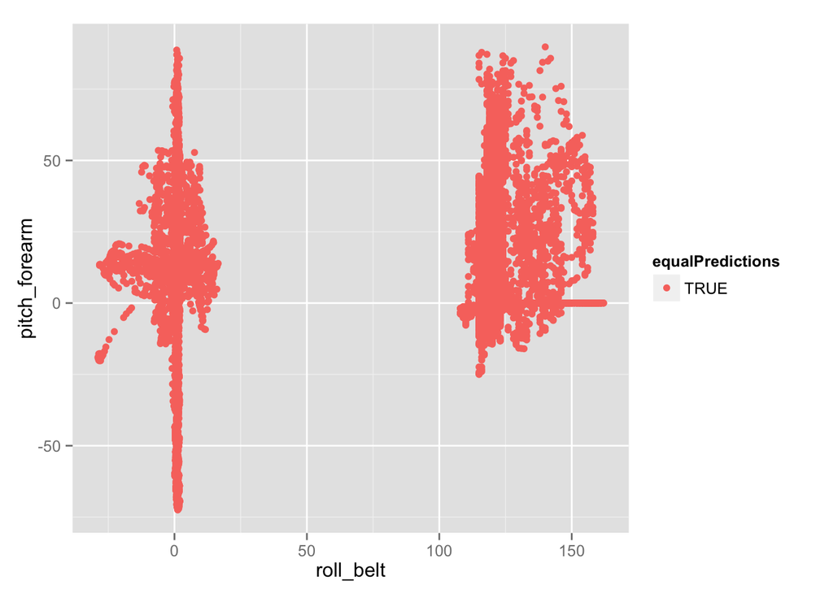

```r
# sweet accuracy of 0.99
pred.rf <- predict(modFit.rf,newdata=training)

equalPredictions = (pred.rf==training$classe)
qplot(roll_belt,pitch_forearm,colour=equalPredictions,data=training)
```

```r
# kk
```

```r
confusionMatrix(pred.rf,training$classe)
```

[output not shown]

We can see from the plot of equal predictions that this method very accurately predicts the classe, at an accuracy rate of 0.99. The trick with Random Forest is that sometimes it overfits, so we will confirm on the out of sample testing/validation dataset that this still holds.

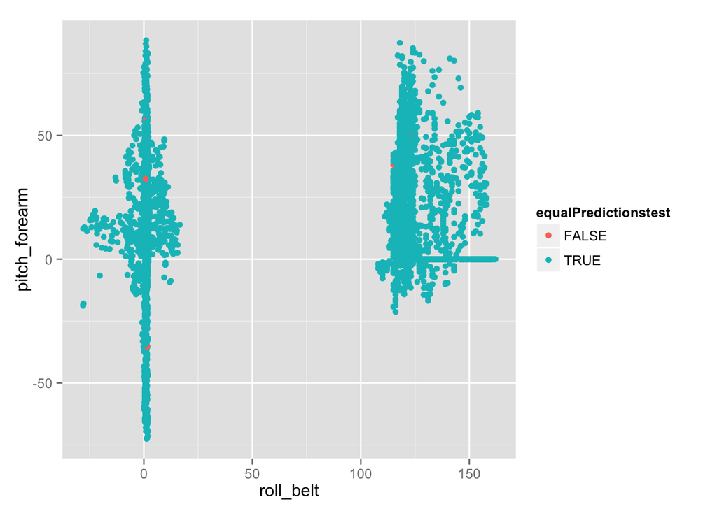

```r
# try a random forest
# now for testing
pred.rftest <- predict(modFit.rf,newdata=testing)
equalPredictionstest = (pred.rftest==testing$classe)
qplot(roll_belt,pitch_forearm,colour=equalPredictionstest,data=testing)
```

```r
confusionMatrix(pred.rftest,testing$classe)
```

```
## Confusion Matrix and Statistics
##
##           Reference
## Prediction    A    B    C    D    E
##          A 1673    7    0    0    0
##          B    1 1132    5    0    0
##          C    0    0 1018    9    0
##          D    0    0    3  953    1
##          E    0    0    0    2 1081
##
## Overall Statistics
##
##                Accuracy : 0.995
##                  95% CI : (0.993, 0.997)
##     No Information Rate : 0.284
##     P-Value [Acc > NIR] : <2e-16
##
##                   Kappa : 0.994
##  Mcnemar's Test P-Value : NA
##
## Statistics by Class:
##
##                      Class: A Class: B Class: C Class: D Class: E
## Sensitivity             0.999    0.994    0.992    0.989    0.999
## Specificity             0.998    0.999    0.998    0.999    1.000
## Pos Pred Value          0.996    0.995    0.991    0.996    0.998
## Neg Pred Value          1.000    0.999    0.998    0.998    1.000
## Prevalence              0.284    0.194    0.174    0.164    0.184
## Detection Rate          0.284    0.192    0.173    0.162    0.184
## Detection Prevalence    0.285    0.193    0.175    0.163    0.184
## Balanced Accuracy       0.999    0.996    0.995    0.994    0.999
```

```r
# accuracy still 0.99
```

Importantly, the accuracy rate is still 0.99 and the plot indicates that the equalPredictions hold to a validation sample.

### References

http://groupware.les.inf.puc-rio.br/har

Velloso, E.; Bulling, A.; Gellersen, H.; Ugulino, W.; Fuks, H. Qualitative Activity Recognition of Weight Lifting Exercises. Proceedings of 4th International Conference in Cooperation with SIGCHI (Augmented Human ’13) . Stuttgart, Germany: ACM SIGCHI, 2013.

Read more: http://groupware.les.inf.puc-rio.br/har#ixzz3paTIccQf